# How many ports do vessels land at?

Emma Fuller

January 17, 2015

Turns out that a fair number of vessels that really split among many ports

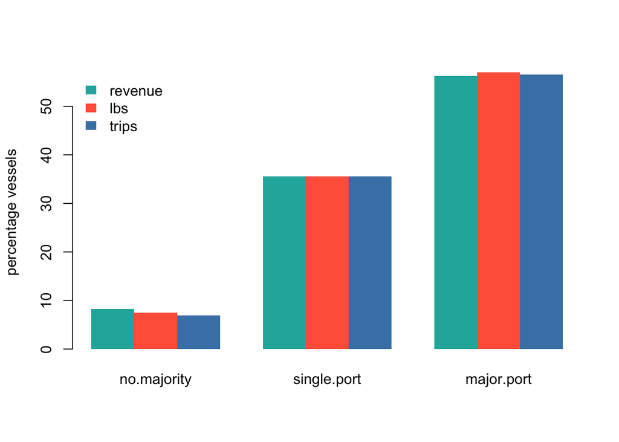

- `no.majority` means that a vessel does not land more than 50% of their trips (measured by revenue, lbs or number of trips) at any single port.
- `single.port` means that a vessel lands 100% of their trips (measured by revenue, lbs, or number of trips) at a single port
- `major.port` means that a vessel lands between 50% and 100% of their trips at a single port.

**Conclusion**: probably should drop vessels for which don’t have at least 50% of trips in a single port, and come back to them later

### Details

Here I took each vessel and first found the percentage that it landed at each of the ports. Then I recorded the maximum of those percentages. I used that maximum percentage to determine whether it landed only at one port (maximum percentage = 1), had a majority (maximum percentage > .5 < 1) or had no majority (maximum percentage < .5). I did this for revenue, pounds landed and number of trips landed.